# My Achievement:

Through this assignment, I explored three major tasks involving clustering on a downsampled MNIST dataset. First, I applied K-means for (k) values from 2 to 10 and evaluated the clusters using both Davies–Bouldin score and distortion, identifying an optimal number of clusters. Next, I performed hierarchical (agglomerative) clustering and visualized the resulting dendrogram to understand how data points merge into clusters at different distance thresholds. Finally, I employed Principal Component Analysis (PCA) to reduce the data from 784 to 28 dimensions and reran K-means, observing lower Davies–Bouldin scores and distortion—indicating more compact, well-separated clusters in the reduced feature space.

# ✍ Student: Mohammad Osmanpoor

# 🏢 University: Macquarie University

# 📅 Assignment: Week 4 Workshop

# task1

my note :

The Davies-Bouldin score, used to evaluate clustering quality, is calculated as $DB = \frac{1}{n_{clusters}} \sum_{i=1}^{n_{clusters}} \max_{j \neq i} \left( \frac{S_i + S_j}{M_{i,j}} \right)$, where $n_{clusters}$ is the number of clusters, $S_i$ is the within-cluster scatter for cluster $i$, and $M_{i,j}$ is the distance between the centroids of clusters $i$ and $j$.

Inertia measures the sum of squared distances between each data point and its assigned cluster centroid, and Distortion, *in this context*, is calculated as $ \text{Distortion} = \sqrt{\frac{\text{Inertia}}{N}} = \sqrt{\frac{\sum_{n=1}^{N} \sum_{k=1}^{K} r_{n,k} ||x_n - \mu_k||^2}{N}}$, where $N$ is the number of data points, $K$ is the number of clusters, $r_{n,k}$ is a binary indicator of whether data point $n$ belongs to cluster $k$, $x_n$ is the $n$-th data point, and $\mu_k$ is the centroid of cluster $k$.

```
k=2: DB score=2.7225, Inertia=214710.13, Distortion=6.3994
k=3: DB score=2.9855, Inertia=200658.22, Distortion=6.1864
k=4: DB score=2.6933, Inertia=190390.33, Distortion=6.0260
k=5: DB score=2.7459, Inertia=183324.20, Distortion=5.9132
k=6: DB score=2.8315, Inertia=177814.56, Distortion=5.8236
k=7: DB score=2.6685, Inertia=173730.04, Distortion=5.7564
k=8: DB score=2.7067, Inertia=169785.96, Distortion=5.6906
k=9: DB score=2.7555, Inertia=166965.68, Distortion=5.6432
k=10: DB score=2.7142, Inertia=164410.55, Distortion=5.5998
```

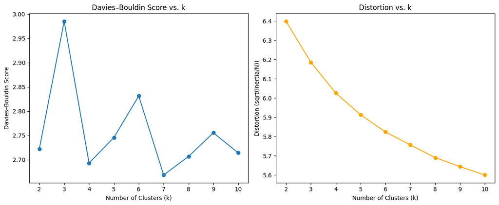

```python
import math
import numpy as np
import pandas as pd
import matplotlib.pyplot as plt

from sklearn.cluster import KMeans
from sklearn.preprocessing import MinMaxScaler
from sklearn.metrics import davies_bouldin_score

# load the MNIST (downsampled) dataset
raw_data = pd.read_csv("mnist-0.1.csv")
X = raw_data.drop("Label", axis=1)  # features
y = raw_data["Label"]              # not used for clustering

# scale the features (range 0 to 1)
scaler = MinMaxScaler()
X_scaled = scaler.fit_transform(X)

# k-means: compute Davies–Bouldin score & Distortion for k=2..10
k_values = range(2, 11)
db_scores = []
distortions = []
inertias = []

for k in k_values:
    kmeans = KMeans(
        n_clusters=k,
        init="k-means++",
        random_state=0,
        n_init=10,
        max_iter=300
    )
    kmeans.fit(X_scaled)

    # labels from clustering
    labels = kmeans.labels_

    # Davies–Bouldin score (lower is better)
    db_score = davies_bouldin_score(X_scaled, labels)
    db_scores.append(db_score)

    # inertia (sum of squared distances to cluster centers)
    inertia = kmeans.inertia_
    inertias.append(inertia)

    # distortion: sqrt(inertia / N)
    distortion = math.sqrt(inertia / X_scaled.shape[0])
    distortions.append(distortion)

    print(f"k={k}: DB score={db_score:.4f}, Inertia={inertia:.2f}, Distortion={distortion:.4f}")

# plot the DB score vs. k and Distortion vs. k in two subplots
fig, ax = plt.subplots(1, 2, figsize=(12, 5))

# Davies–Bouldin Score vs. k
ax[0].plot(k_values, db_scores, marker='o')
ax[0].set_title("Davies–Bouldin Score vs. k")
ax[0].set_xlabel("Number of Clusters (k)")
ax[0].set_ylabel("Davies–Bouldin Score")

# distortion vs. k
ax[1].plot(k_values, distortions, marker='o', color='orange')
ax[1].set_title("Distortion vs. k")
ax[1].set_xlabel("Number of Clusters (k)")
ax[1].set_ylabel("Distortion (sqrt(Inertia/N))")

plt.tight_layout()
plt.show()


# I think if our goal is the best clustering quality (DB) → we can use k = 7
# and if we want a more interpretable model with fewer clusters and low distortion → we can choose k = 4 or 5
```

# task2

when I read the documentation of sklearn and scipy, I found out that we have different type of agglomerative clustering. 'single', 'average', 'ward', 'complete'. but for this task, I followed the tutorial of this assignment and used the `complete method( because you have used this method in your tutorial).

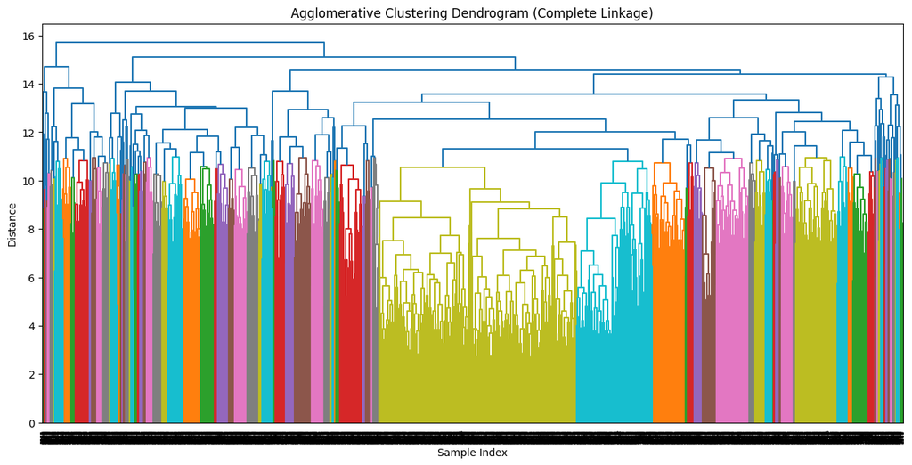

```python
import pandas as pd
import numpy as np
import matplotlib.pyplot as plt

from sklearn.preprocessing import MinMaxScaler
from scipy.cluster.hierarchy import dendrogram, linkage
from scipy.spatial.distance import pdist

# load the data
raw_data = pd.read_csv("mnist-0.1.csv")
X = raw_data.drop("Label", axis=1)
y = raw_data["Label"]  # not used for clustering, only for reference if needed

# scale the features (range 0 to 1)
scaler = MinMaxScaler()
X_scaled = scaler.fit_transform(X)

# compute the pairwise distance matrix
dist_matrix = pdist(X_scaled, metric='euclidean')

# perform hierarchical clustering using 'complete' linkage
linkage_matrix = linkage(dist_matrix, method='complete')

# visualize the hierarchy via a dendrogram
plt.figure(figsize=(15, 7))
dendrogram(linkage_matrix)
plt.title("Agglomerative Clustering Dendrogram (Complete Linkage)")
plt.xlabel("Sample Index")
plt.ylabel("Distance")
plt.show()
```

# task 3

MNIST has 784 features (one per pixel) and with PCA, I project this data into a smaller subspace while retaining the bulk of its variance. this reducing dimensionality can speed up clustering and reduce memory usage.and also because PCA often discards noisy components, potentially improving clustering quality. for this task I used `PCA` method, but I found out that also exist other methods like `t-SNE` and `UMAP` that are accessible from `sklearn`, `openTSNE`, `umap-learn` libraries.

```
Original shape: (5243, 784)
Reduced shape after PCA: (5243, 28)
k=2, DB score=2.2927, Inertia=151773.69, Distortion=5.3803
k=3, DB score=2.4578, Inertia=137749.84, Distortion=5.1257
k=4, DB score=2.1981, Inertia=127500.40, Distortion=4.9314
k=5, DB score=2.2228, Inertia=120460.02, Distortion=4.7933
k=6, DB score=2.2613, Inertia=114988.22, Distortion=4.6831
k=7, DB score=2.1259, Inertia=111003.63, Distortion=4.6013
k=8, DB score=2.1212, Inertia=107106.60, Distortion=4.5198
k=9, DB score=2.1595, Inertia=104340.51, Distortion=4.4610
k=10, DB score=2.1739, Inertia=101845.17, Distortion=4.4074
```

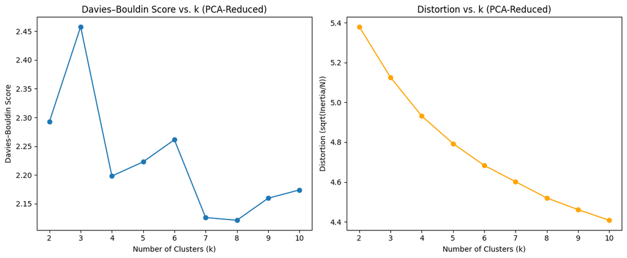

```python
import math
import numpy as np
import pandas as pd
import matplotlib.pyplot as plt

from sklearn.preprocessing import MinMaxScaler
from sklearn.decomposition import PCA
from sklearn.cluster import KMeans
from sklearn.metrics import davies_bouldin_score

# load the MNIST (downsampled) dataset
raw_data = pd.read_csv("mnist-0.1.csv")
X = raw_data.drop("Label", axis=1)
y = raw_data["Label"]  # not used for clustering, only for reference

# scale the features to [0, 1]
scaler = MinMaxScaler()
X_scaled = scaler.fit_transform(X)

# apply PCA for dimensionality reduction
# number of components: sqrt(784) = 28 : I used heuristic sqrt(#original_feature) to reduce dimensionality while retaining a significant portion of the variance.
n_components = int(np.sqrt(X_scaled.shape[1]))  # 28 if 784 features
pca = PCA(n_components=n_components, random_state=0)
X_reduced = pca.fit_transform(X_scaled)

print(f"Original shape: {X_scaled.shape}")
print(f"Reduced shape after PCA: {X_reduced.shape}")

# evaluate K-means on the reduced data
k_values = range(2, 11)
db_scores_pca = []
distortions_pca = []
inertias_pca = []

for k in k_values:
    kmeans = KMeans(
        n_clusters=k,
        init="k-means++",
        random_state=0,
        n_init=10,
        max_iter=300
    )
    kmeans.fit(X_reduced)

    labels = kmeans.labels_
    db_score = davies_bouldin_score(X_reduced, labels)
    inertia = kmeans.inertia_
    distortion = math.sqrt(inertia / X_reduced.shape[0])

    db_scores_pca.append(db_score)
    distortions_pca.append(distortion)
    inertias_pca.append(inertia)

    print(f"k={k}, DB score={db_score:.4f}, Inertia={inertia:.2f}, Distortion={distortion:.4f}")

# plot the DB scores and distortion vs. k for PCA-reduced data
fig, ax = plt.subplots(1, 2, figsize=(12, 5))

# Davies–Bouldin Score
ax[0].plot(k_values, db_scores_pca, marker='o')
ax[0].set_title("Davies–Bouldin Score vs. k (PCA-Reduced)")
ax[0].set_xlabel("Number of Clusters (k)")
ax[0].set_ylabel("Davies–Bouldin Score")

# Distortion
ax[1].plot(k_values, distortions_pca, marker='o', color='orange')
ax[1].set_title("Distortion vs. k (PCA-Reduced)")
ax[1].set_xlabel("Number of Clusters (k)")
ax[1].set_ylabel("Distortion (sqrt(Inertia/N))")

plt.tight_layout()
plt.show()
```

## compare the DB score and distortion before and after PCA.

By reducing the data from 784 to 28 dimensions, PCA removes redundant or noisy features and makes the clusters more compact, as shown by the consistently lower Davies–Bouldin scores (2.29 vs. 2.72 at k=2) and lower distortion values (5.38 vs. 6.40 at k=2). In contrast, without PCA, the high-dimensional data yields higher DB scores and distortion, indicating less compact clusters. Overall, applying PCA appears to improve cluster separation and compactness for this MNIST subset, making K-means more effective in the reduced feature space. In this task i used root(number of features) for specifying the number of components ( that is simple heuristic), But in future I will use lower number of components and find the minimum components that we can use for this dataset without noticable dropping performance.